# STAT 685 - Directed Studies

Ken Marciel

2/7/2022

# Risk Factors for Postoperative Nausea and Vomiting (PONV)

The incidence of post-operative nausea and vomiting (PONV) is generally in the range of 20-40% (Apfel **et al**). There are several well-documented models for predicting PONV, to help guide prudent administration of prophylaxis. These models are typically developed using logistic regression and stepwise backward elimination for variable selection. The most common measure of accuracy for these models is the area under the receiver operating characteristic curve (ROC). These AUC values tend to fall in the range of 0.6 to 0.7 (Thomas **et al**, van den Bosch **et al**).

## Packages

```r
library(dplyr) # rename variables
library(alr4) # marginal model plots
library(leaps) # regression subset plots
library(car) # regression subset plots
library(rms) # logistic regression
library(pROC) # ROC curve
library(caret) # data splitting, resampling
```

## Data set

```r
# Obtain raw data set
path <- 'C:/Users/keoka/OneDrive - Texas A&M University/Courses/STAT_685/Data'
setwd(path) # set working directory to location of data file
ponv <- read.csv('PONV.csv') # read data from file

# Review data set
#class(ponv) # data frame
#dim(ponv) # 916 rows, 26 columns
#str(ponv) # display structure of data set
#names(ponv) # display names of variables in data set
# Rename selected variables
ponv <- rename(ponv,
               AgeOver50 = Ageover50,
               AnesthesiaDuration = Anaesthesiaduration,
               AnesthesiaOverHour = Anaesthesiaoverhour,
               Nonsmoker = Smoking,
               KinetosisHistory = Kinethosishist,
               PONVhistory = PONVhist,
               SerotoninBlocker = Serotoninblock)
#summary(ponv) # all columns are encoded as numeric values
#head(ponv) # display first 6 rows
#tail(ponv) # display last 6 rows

# Clean data set
ponv <- ponv[complete.cases(ponv),] # remove rows with missing values
#dim(ponv) # 916 rows, 26 columns (none of the records have missing values)
ponv <- unique(ponv) # remove duplicate records
#dim(ponv) # 823 rows, 26 columns (93 duplicate rows removed)
```

The raw data set has 916 rows and 26 columns. None of the rows have missing values. After removing the 93 duplicates, the cleaned data set has 823 rows and 26 columns.

## Sample size

```r
attach(ponv)
# Identify number of records of patients who took prophylaxis = 362
#nrow(ponv[Glukocorticoid==1 | Metoklopramid==1 | Serotoninblock==1,])
# Remove 362 records of patients who took prophylaxis
ponv <- ponv[Glukocorticoid==0 & Metoklopramid==0 & SerotoninBlocker==0,]
detach(ponv)

# Review data set.
#dim(ponv) # 461 rows, 26 columns (362 rows removed)
n <- nrow(ponv) # sample size = 461
```

After removing the 362 records of patients who took prophylaxis, the data set now has 461 rows and 26 columns.

## Variables

```r
names(ponv) # column names for the 26 variables in the original data set
```

```
##  [1] "Patient"            "AgeOver50"          "Age"
##  [4] "Gender"             "Diagnosis"          "Surgery"
##  [7] "AnesthesiaDuration" "AnesthesiaOverHour" "Weight"
## [10] "BMI"                "Nonsmoker"          "KinetosisHistory"
## [13] "PONVhistory"        "Glukocorticoid"     "Metoklopramid"
## [16] "SerotoninBlocker"   "Cormackliheene"     "PONV0to2"
## [19] "PONV2to24"          "PONV0to24"          "Headache0to2"
## [22] "Headache2to24"      "Headache0to24"      "SinclairScore"
## [25] "ApfelScore"         "LelaScore"
```

Next, we will make sure that the original 26 variables are properly encoded for data analysis.

```r
# Identification variable = 1
Patient <- as.character(ponv$Patient) # integer changed to character

# Response variables = 9
PONV0to2 <- as.factor(ponv$PONV0to2) # integer changed to factor
PONV2to24 <- as.factor(ponv$PONV2to24) # integer changed to factor
PONV0to24 <- as.factor(ponv$PONV0to24) # integer changed to factor
Headache0to2 <- as.factor(ponv$Headache0to2) # integer changed to factor
Headache2to24 <- as.factor(ponv$Headache2to24) # integer changed to factor
Headache0to24 <- as.factor(ponv$Headache0to24) # integer changed to factor
SinclairScore <- ponv$SinclairScore # numeric
ApfelScore <- ponv$ApfelScore # numeric
LelaScore <- ponv$LelaScore # integer

# Predictor variables = 16
AgeOver50 <- as.factor(ponv$AgeOver50) # integer changed to factor
Age <- ponv$Age # integer
Gender <- as.factor(ponv$Gender) # integer changed to factor
Diagnosis <- as.factor(ponv$Diagnosis) # integer changed to factor
Surgery <- as.factor(ponv$Surgery) # numeric changed to factor
AnaesthesiaDuration <- ponv$AnaesthesiaDuration # integer
AnaesthesiaOverHour <- as.factor(ponv$AnaesthesiaOverHour) # integer changed to factor
Weight <- ponv$Weight # numeric
BMI <- ponv$BMI # numeric
Nonsmoker <- as.factor(ponv$Nonsmoker) # integer changed to factor
KinetosisHistory <- as.factor(ponv$KinetosisHistory) # integer changed to factor
PONVhistory <- as.factor(ponv$PONVhistory) # integer changed to factor
Glukocorticoid <- as.factor(ponv$Glukocorticoid) # integer changed to factor
Metoklopramid <- as.factor(ponv$Metoklopramid) # integer changed to factor
SerotoninBlocker <- as.factor(ponv$SerotoninBlocker) # integer changed to factor
Cormackliheene <- as.factor(ponv$Cormackliheene) # numeric changed to factor
```

The 26 variables from the original data set consist of the ID variable, 9 response variables, and 16 predictor variables.

## Variables considered for analysis of PONV incidence within 24 hours

Response variable selected:

$Y$ = PONV0to24 (binary) = incidence of PONV within 24 hours of operation

For the purpose of developing a predictive model for PONV, we exclude the eight predictor variables corresponding to anesthetic and postoperative patient risk factors. In the full model, we consider the remaining eight predictor variables corresponding to the preoperative patient risk factors:

$x_{1}$ = Age (integer)  
$x_{2}$ = Gender (binary)  
$x_{3}$ … $x_{27}$ = Diagnosis (categorical with 26 levels)  
$x_{28}$ … $x_{34}$ = Surgery (categorical with 8 levels)  
$x_{35}$ = BMI (real)  
$x_{36}$ = Nonsmoker (binary)  
$x_{37}$ = Kinetosis history (binary)  
$x_{38}$ = PONV history (binary)

The model includes 25 dummy variables for the 26 levels of *Diagnosis*, and 7 dummy variables for the 8 levels of *Surgery*. This is a total of 38 variables, when the factors with more than two levels are taken into full account.

```r
# Data set for regression analysis of PONV incidence within 24 hours
ponv <- data.frame(Patient, # ID variable
                  PONV0to24, # response variable
                  # 8 predictor variables
                  Age, Gender, Diagnosis, Surgery,
                  BMI, Nonsmoker, KinetosisHistory, PONVhistory)
#class(ponv) # data frame
#dim(ponv) # 461 rows, 10 columns
n <- nrow(ponv) # sample size = 461
p <- ncol(ponv) - 2 # predictor variables for full model = 8
# Observed incidence of PONV = 37.3%
PONVincidence = sum(as.numeric(ponv$PONV0to24)-1) /
  length(as.numeric(ponv$PONV0to24)-1)
```

The 10 variables in the data set for the full model consist of the ID variable, the response variable, and 8 predictor variables. The observed incidence of PONV for this data set is 0.37.

## Full model for logistic regression

We begin by considering the following generalized linear model for the binary response variable:

$Y=g(\beta_{0}+\beta_{1}x_{1}+\beta_{2}x_{2}+\beta_{3}x_{3}+...+\beta_{27}x_{27}+\beta_{28}x_{28}+...+\beta_{34}x_{34}+\beta_{35}x_{35}+\beta_{36}x_{36}+\beta_{37}x_{37}+\beta_{38}x_{38}+e)$

where *e* ~ iid $N(0,1)$.

To model the binary response variable through a generalized linear model, we use the log odds ratio (logit) as the link function as follows:

$g^{-1}(Y)=\log(\frac{\theta(Y)}{1-\theta(Y)})=\beta_{0}+\beta_{1}x_{1}+\beta_{2}x_{2}+\beta_{3}x_{3}+...+\beta_{27}x_{27}+\beta_{28}x_{28}+...+\beta_{34}x_{34}+\beta_{35}x_{35}+\beta_{36}x_{36}+\beta_{37}x_{37}+\beta_{38}x_{38}+e$

$\theta$ is the parameter of the binomial distribution, which is related to a transformation of the logit as follows:

$\theta(Y)=\frac{\exp(Y)}{1+\exp(Y)}=\frac{1}{1+{\exp(-Y)}}$

For this analysis, our $\theta$ of interest is the proportion of patients diagnosed with PONV within the 24 hours following surgery.

The logistic regression model is fitted using the generalized linear method of least squares:

```r
# Use glm (generalized linear model) function to fit logistic regression
glmFit1 <- glm(PONV0to24 ~ Age + Gender + Diagnosis + Surgery +
                 BMI + Nonsmoker + KinetosisHistory + PONVhistory,
               family = binomial, data = ponv)
summary(glmFit1)
```

```
##
## Call:
## glm(formula = PONV0to24 ~ Age + Gender + Diagnosis + Surgery +
##     BMI + Nonsmoker + KinetosisHistory + PONVhistory, family = binomial,
##     data = ponv)
##
## Deviance Residuals:
##     Min       1Q   Median       3Q      Max
## -1.7753  -0.9663  -0.5579   1.1567   2.3369
##
## Coefficients:
##                     Estimate Std. Error z value Pr(>|z|)
## (Intercept)       -1.817e+01  1.171e+03  -0.016   0.9876
## Age               -3.662e-03  8.834e-03  -0.415   0.6785
## Gender1            8.547e-01  3.217e-01   2.656   0.0079 **
## Diagnosis1         9.179e-01  6.314e-01   1.454   0.1460
## Diagnosis2         1.079e+00  5.780e-01   1.868   0.0618 .
## Diagnosis3         1.081e+00  7.968e-01   1.357   0.1748
## Diagnosis4         1.108e+00  6.124e-01   1.809   0.0705 .
## Diagnosis5        -1.851e-01  8.955e-01  -0.207   0.8362
## Diagnosis6         1.136e+00  9.282e-01   1.224   0.2211
## Diagnosis7         1.493e+00  1.674e+00   0.892   0.3726
## Diagnosis8        -7.698e-01  1.217e+00  -0.632   0.5272
## Diagnosis9        -6.555e-01  1.450e+00  -0.452   0.6513
## Diagnosis10        1.634e+00  2.022e+00   0.808   0.4191
## Diagnosis11       -1.439e+01  2.400e+03  -0.006   0.9952
## Diagnosis12       -1.392e+01  1.696e+03  -0.008   0.9935
## Diagnosis13       -3.879e-02  8.915e-01  -0.044   0.9653
## Diagnosis14        1.801e+01  1.223e+03   0.015   0.9883
## Diagnosis15        6.021e-01  8.127e-01   0.741   0.4587
## Diagnosis16        7.782e-01  9.200e-01   0.846   0.3976
## Diagnosis17       -1.397e+01  1.340e+03  -0.010   0.9917
## Diagnosis18        1.664e+01  2.400e+03   0.007   0.9945
## Diagnosis19        5.787e-01  9.616e-01   0.602   0.5473
## Diagnosis20        8.271e-01  1.384e+00   0.598   0.5500
## Diagnosis23        1.838e+01  2.400e+03   0.008   0.9939
## Diagnosis24       -1.458e+01  2.400e+03  -0.006   0.9952
## Diagnosis25        1.896e+01  2.400e+03   0.008   0.9937
## Surgery1           1.530e+01  1.171e+03   0.013   0.9896
## Surgery2           1.522e+01  1.171e+03   0.013   0.9896
## Surgery3           3.240e+01  2.670e+03   0.012   0.9903
## Surgery4           1.548e+01  1.171e+03   0.013   0.9894
## Surgery5          -2.295e+00  1.693e+03  -0.001   0.9989
## Surgery7           1.426e+01  1.171e+03   0.012   0.9903
## BMI                2.241e-02  2.415e-02   0.928   0.3536
## Nonsmoker1         5.353e-01  2.454e-01   2.181   0.0292 *
## KinetosisHistory1  8.598e-02  4.972e-01   0.173   0.8627
## PONVhistory1       1.432e+00  3.414e-01   4.194 2.74e-05 ***
## ---
## Signif. codes:  0 '***' 0.001 '**' 0.01 '*' 0.05 '.' 0.1 ' ' 1
##
## (Dispersion parameter for binomial family taken to be 1)
##
##     Null deviance: 609.06  on 460  degrees of freedom
## Residual deviance: 522.95  on 425  degrees of freedom
## AIC: 594.95
##
## Number of Fisher Scoring iterations: 15
```

Three of the predictors in the full model have estimated coefficients that are statistically significant. In descending order of significance, these are PONV history, gender, and nonsmoker.

### Plots of standardized deviance residuals

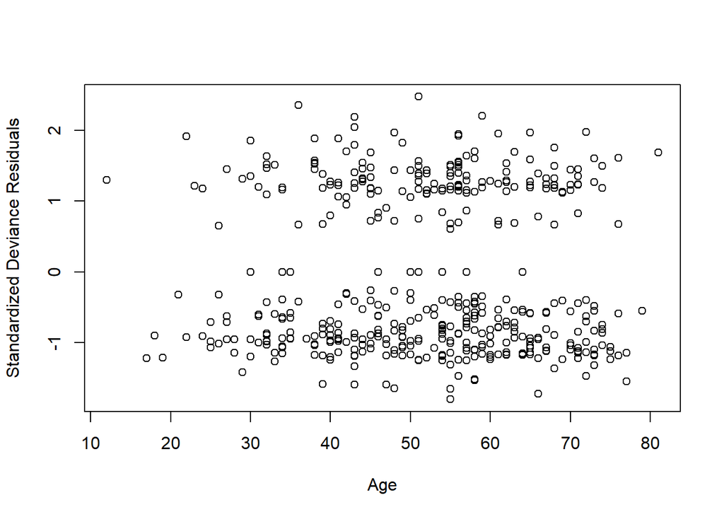

```r
# Hat matrix
hval.glmFit1 <- influence(glmFit1)$hat

# Standardized deviance residuals
stanresDev.glmFit1 <- residuals(glmFit1)/sqrt(1-hval.glmFit1)

plot(Age, stanresDev.glmFit1,
     ylab = "Standardized Deviance Residuals", xlab = "Age")
```

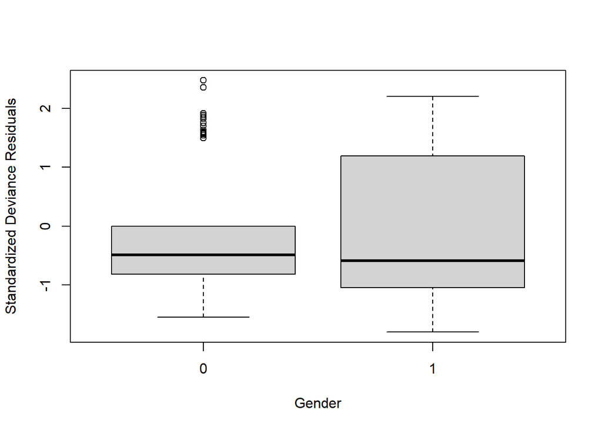

```r
plot(Gender, stanresDev.glmFit1,
     ylab = "Standardized Deviance Residuals", xlab = "Gender")
```

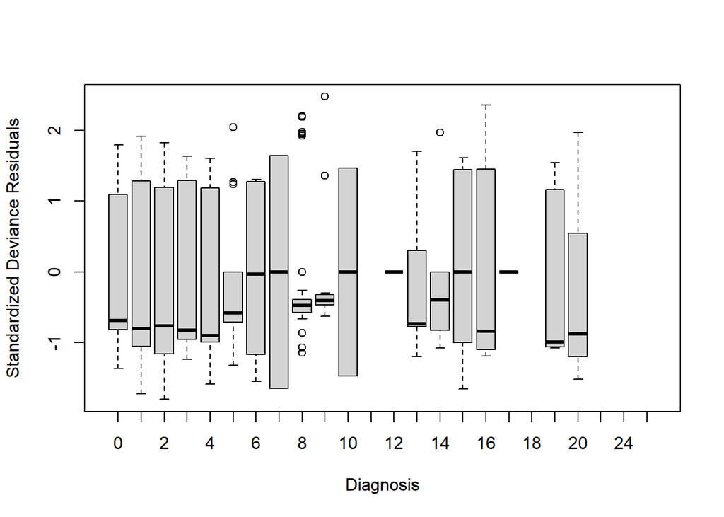

```r
plot(Diagnosis, stanresDev.glmFit1,
     ylab = "Standardized Deviance Residuals", xlab = "Diagnosis")
```

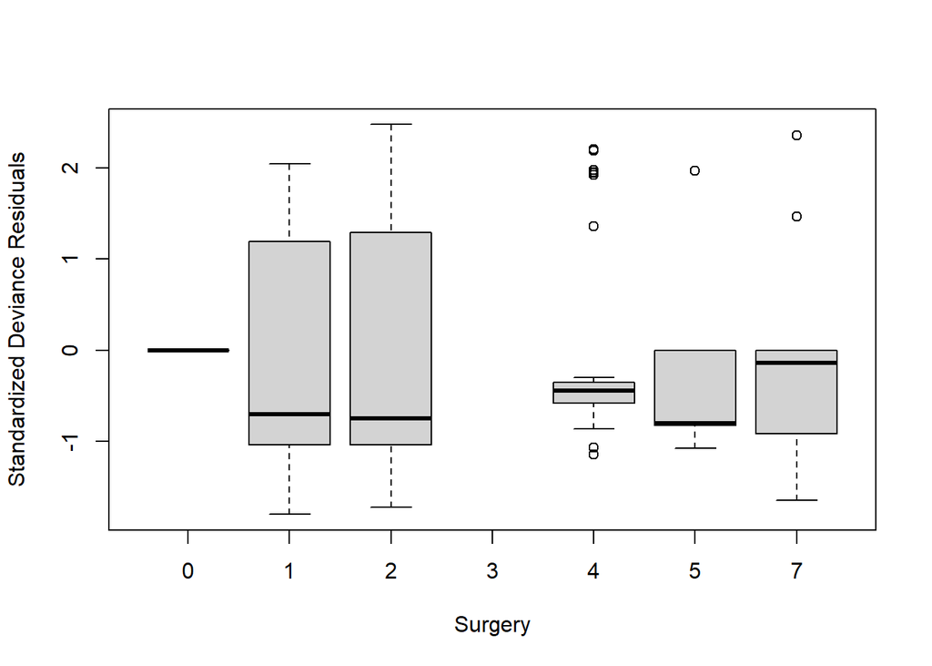

```r
plot(Surgery, stanresDev.glmFit1,
     ylab = "Standardized Deviance Residuals", xlab = "Surgery")
```

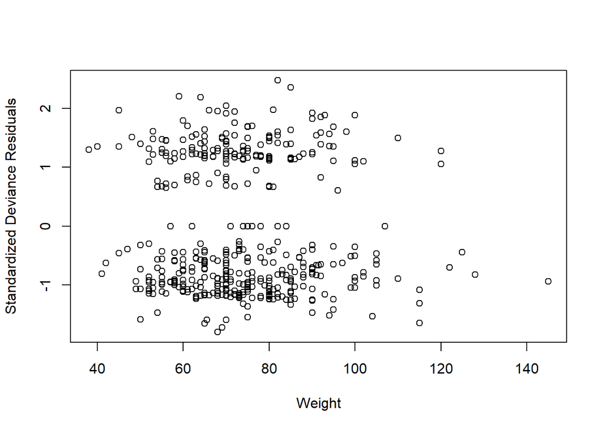

```r
plot(Weight, stanresDev.glmFit1,
     ylab = "Standardized Deviance Residuals", xlab = "Weight")
```

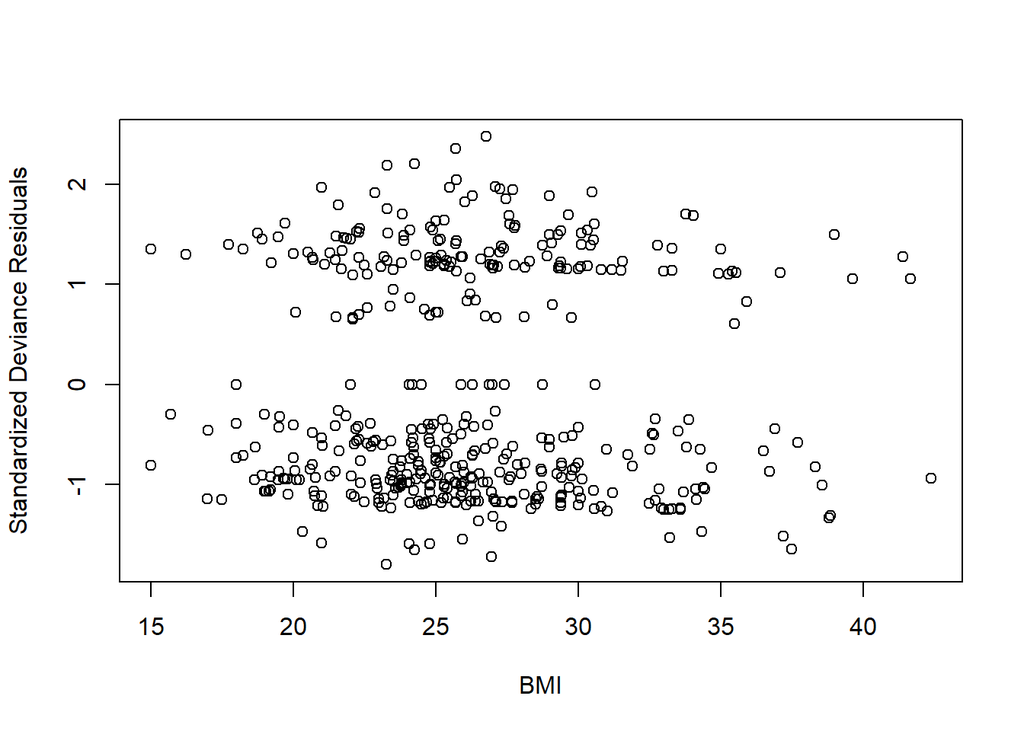

```r
plot(BMI, stanresDev.glmFit1,
     ylab = "Standardized Deviance Residuals", xlab = "BMI")
```

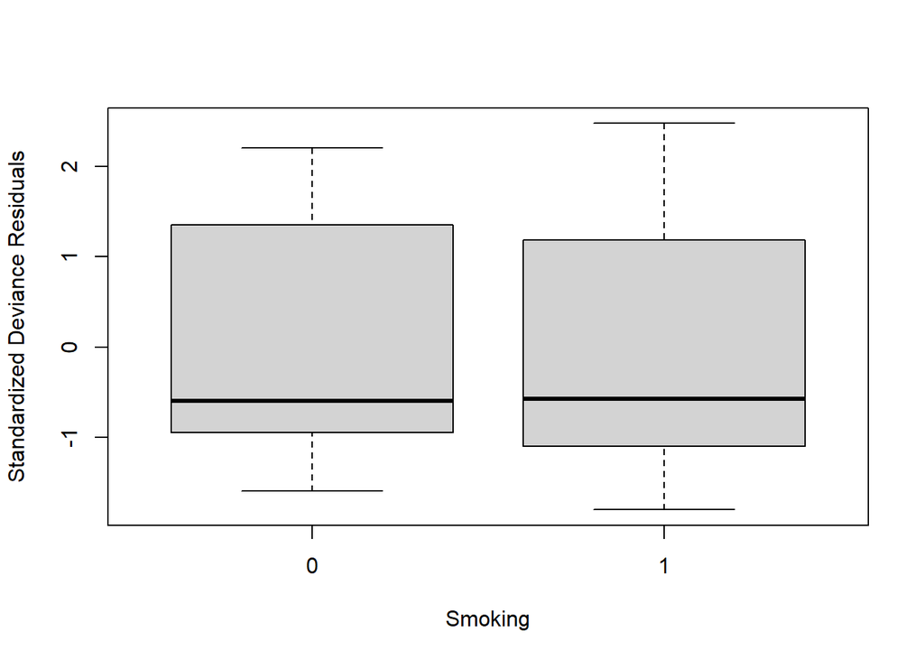

```r
plot(Nonsmoker, stanresDev.glmFit1,
     ylab = "Standardized Deviance Residuals", xlab = "Smoking")
```

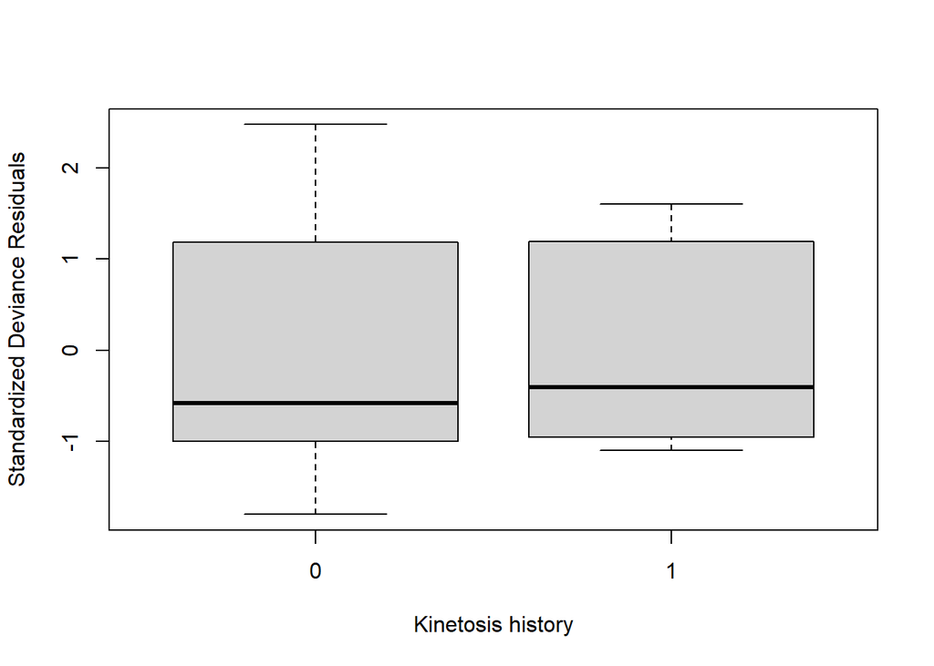

```r
plot(KinetosisHistory, stanresDev.glmFit1,
     ylab = "Standardized Deviance Residuals", xlab = "Kinetosis history")
```

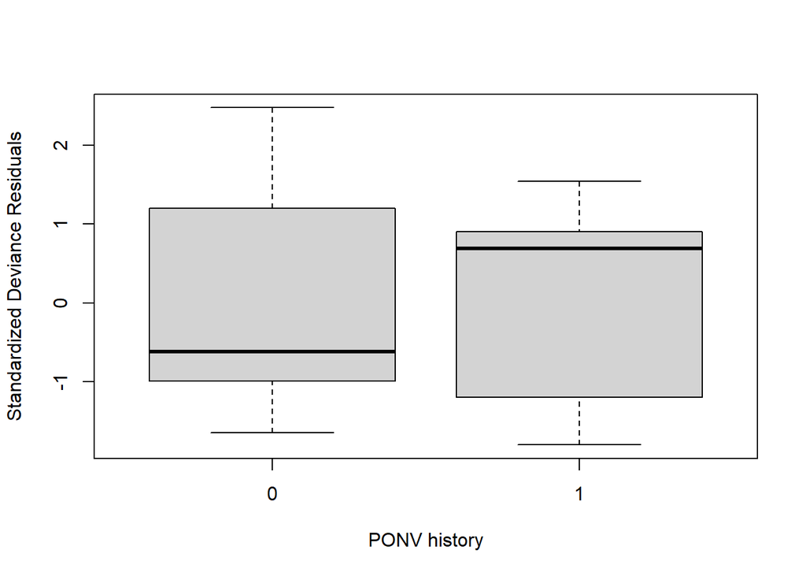

```r
plot(PONVhistory, stanresDev.glmFit1,
     ylab = "Standardized Deviance Residuals", xlab = "PONV history")
```

Skewness is present in all of the predictors, most of which are right-skewed. This suggests that the log odds may depend on each skewed predictor through both a linear function and a log transformation. However, residual plots are difficult to interpret for binary data, so we will examine marginal model plots instead.

### Marginal model plots for the continuous predictors

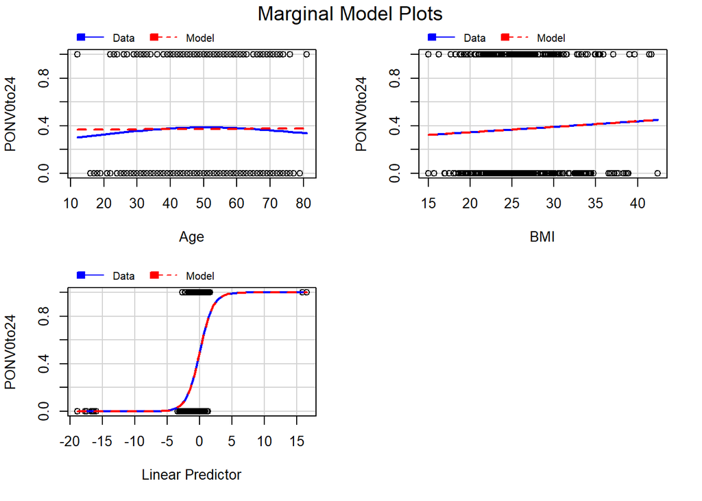

```r
mmps(glmFit1) # marginal model plots displayed altogether in two-column format
```

```r
#mmp(glmFit1,Age); mmp(glmFit1,BMI); mmp(glmFit1) # to view plots individually
```

There is reasonable agreement between the two fits in each of the marginal model plots for BMI and the linear predictor. Due to the lack of fit for Age, and the presence of parabolic curvature for the observed response, one possible approach is to consider adding a quadratic term for Age.

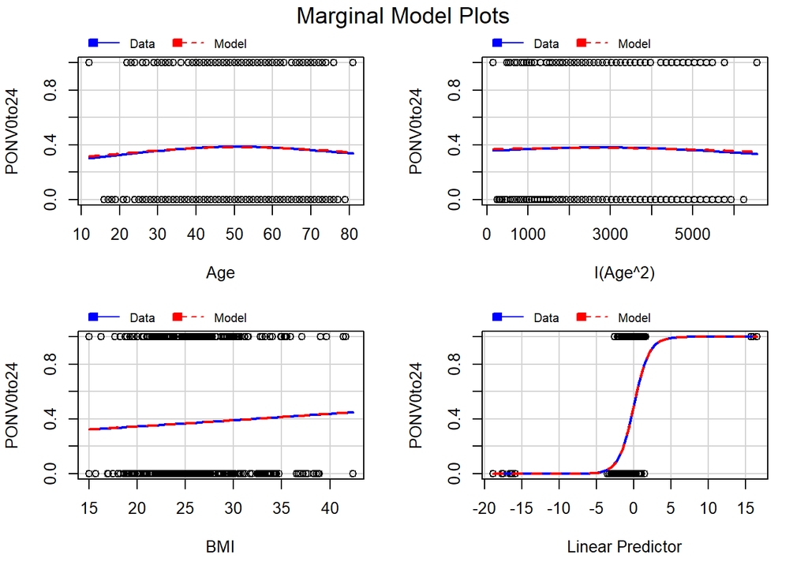

```r
# Add a quadratic term for age to the model
glmFit2 <- glm(PONV0to24 ~ Age + I(Age^2) + Gender + Diagnosis + Surgery + BMI +
           Nonsmoker + KinetosisHistory + PONVhistory,
           family = binomial, data = ponv)
#summary(glmFit2)
mmps(glmFit2)
```

After adding a quadratic term for age, there is reasonable agreement between the two fits in each of the marginal model plots for $Age$, $Age^2$, $BMI$, and the linear predictor. This indicates that the current model is an adequate fit for the data.

### Leverage values and standardized deviance residuals

As a final validity check, we examine leverage values and standardized deviance residuals.

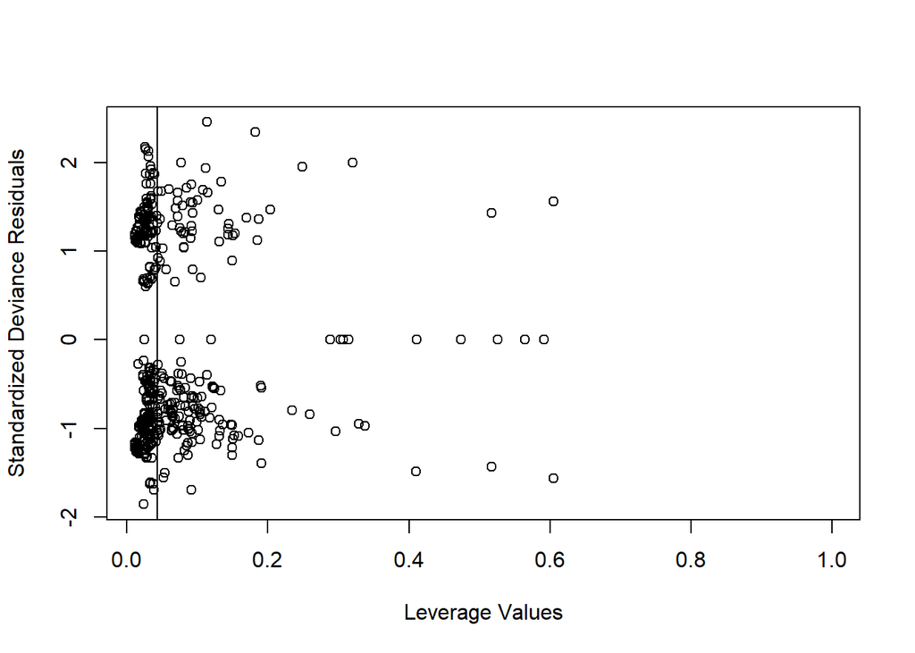

```
## integer(0)
```

```r
hval.glmFit2 <- influence(glmFit2)$hat # hat matrix (leverage values)
p2 <- p + 1 # 10 predictors = 9 linear predictors plus quadratic term for Age
avgLev.glmFit2 <- (p2 + 1) / n  # average leverage
cutLev.glmFit2 <- 2 * avgLev.glmFit2  # cutoff for high leverage
stanresDev.glmFit2 <- residuals(glmFit2)/sqrt(1-hval.glmFit2) # standardized deviance residuals
plot(hval.glmFit2, stanresDev.glmFit2,
     ylab = "Standardized Deviance Residuals",
     xlab = "Leverage Values")
abline(v = cutLev.glmFit2)
identify(hval.glmFit2, stanresDev.glmFit2, labels = Patient)
```

A plot of leverage values and standardized deviance residuals reveals that none of the leverage points exceed 2.5 standard deviations. Six of the points exceed two standard deviations and should be investigated. However, since these points comprise only 1% of the 461 values in the data set, we will continue with the assumption that the current model is an adequate fit for the data. Therefore, we next proceed to variable selection.

## Variable selection using all possible subsets

### Plots of $R^2_{adj}$ against subset size for the best subset of each size

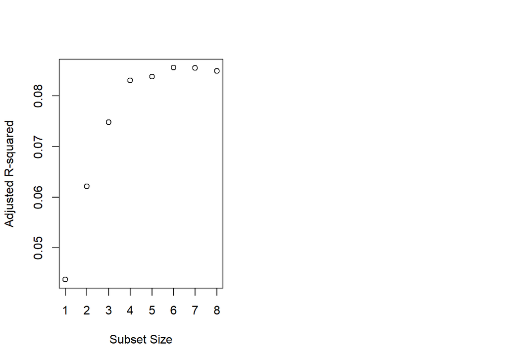

```r
Age2 <- Age^2
X <- cbind(Age, Age2, Gender, Diagnosis, Surgery, BMI, Nonsmoker,
           KinetosisHistory, PONVhistory)
b <- regsubsets(as.matrix(X), PONV0to24)
rs <- summary(b)
par(mfrow = c(1,2))
plot(1:8, rs$adjr2, xlab = "Subset Size", ylab = "Adjusted R-squared")
#subsets(b, statistic = c("adjr2"))
```

The plot of adjusted $R^2$ values shows the best predictor subsets to be as follows:

1 predictor: PONVhist  
2 predictors: Surgery, PONVhist  
3 predictors: Gender, Surgery, PONVhist  
4 predictors: Gender, Surgery, Nonsmoker, PONVhist  
5 predictors: Age$^2$, Gender, Surgery, Nonsmoker, PONVhist  
6 predictors: Age$^2$, Gender, Surgery, BMI, Nonsmoker, PONVhist  
7 predictors: Age, Age$^2$, Gender, Surgery, BMI, Nonsmoker, PONVhist  
8 predictors: Age, Age$^2$, Gender, Surgery, BMI, Nonsmoker, KinetosisHist, PONVhist

Viewing the results of the adjusted $R^2$ plot another way, the number of models that include each variable is as follows:

8 models: PONVhist  
7 models: Surgery  
6 models: Gender  
5 models: Nonsmoker  
4 models: Age$^2$  
3 models: BMI  
2 models: Age  
1 model: KinetosisHist

### Values of $R^2_{adj}$, AIC, AIC$_{C}$, and BIC for the best subset of each size

The predictor with the smallest *p*-value for its estimated coefficient is added to each subset to obtain the next subset.

```r
# Subset size = 1
om1 <- glm(PONV0to24 ~ PONVhistory, family = binomial, data = ponv)
# Subset size = 2
om2 <- glm(PONV0to24 ~ PONVhistory + Gender, family = binomial, data = ponv)
# Subset size = 3
om3 <- glm(PONV0to24 ~ PONVhistory + Gender + Nonsmoker, family = binomial,
          data = ponv)
# Subset size = 4
om4 <- glm(PONV0to24 ~ PONVhistory + Gender + Nonsmoker + Diagnosis,
          family = binomial, data = ponv)
# Subset size = 5
om5 <- glm(PONV0to24 ~ PONVhistory + Gender + Nonsmoker + Diagnosis + I(Age^2),
          family = binomial, data = ponv)
# Subset size = 6
om6 <- glm(PONV0to24 ~ PONVhistory + Gender + Nonsmoker + Diagnosis + I(Age^2)
           + Age, family = binomial, data = ponv)
# Subset size = 7
om7 <- glm(PONV0to24 ~ PONVhistory + Gender + Nonsmoker + Diagnosis + I(Age^2)
           + Age + BMI, family = binomial, data = ponv)
# Subset size = 8
om8 <- glm(PONV0to24 ~ PONVhistory + Gender + Nonsmoker + Diagnosis + I(Age^2)
           + Age + BMI + KinetosisHistory, family = binomial, data = ponv)
# Subset size = 9
om9 <- glmFit2
```

### Calculate AIC

```r
extractAIC(om1, k = 2)
```

```
## [1]   2.000 592.694
```

```r
extractAIC(om2, k = 2)
```

```
## [1]   3.0000 584.9411
```

```r
extractAIC(om3, k = 2)
```

```
## [1]   4.0000 581.9543
```

```r
extractAIC(om4, k = 2)
```

```
## [1]  27.0000 586.0426
```

```r
extractAIC(om5, k = 2)
```

```
## [1]  28.0000 587.7882
```

```r
extractAIC(om6, k = 2)
```

```
## [1]  29.0000 587.6944
```

```r
extractAIC(om7, k = 2)
```

```
## [1]  30.0000 589.4248
```

```r
extractAIC(om8, k = 2)
```

```
## [1]  31.0000 591.3129
```

```r
extractAIC(om9, k = 2)
```

```
## [1]  37.0000 594.5913
```

The minimum value of AIC corresponds to the predictor subset of size three: PONVhistory, Gender, and Nonsmoker

### Calculate AIC$_{C}$

```r
npar.1 <- length(om1$coefficients) + 1
npar.2 <- length(om2$coefficients) + 1
npar.3 <- length(om3$coefficients) + 1
npar.4 <- length(om4$coefficients) + 1
npar.5 <- length(om5$coefficients) + 1
npar.6 <- length(om6$coefficients) + 1
npar.7 <- length(om7$coefficients) + 1
npar.8 <- length(om8$coefficients) + 1
npar.9 <- length(om9$coefficients) + 1

extractAIC(om1, k = 2) + 2 * npar.1 * (npar.1 + 1) / (n - npar.1 - 1)
```

```
## [1]   2.052516 592.746551
```

```r
extractAIC(om2, k = 2) + 2 * npar.2 * (npar.2 + 1) / (n - npar.2 - 1)
```

```
## [1]   3.087719 585.028857
```

```r
extractAIC(om3, k = 2) + 2 * npar.3 * (npar.3 + 1) / (n - npar.3 - 1)
```

```
## [1]   4.131868 582.086134
```

```r
extractAIC(om4, k = 2) + 2 * npar.4 * (npar.4 + 1) / (n - npar.4 - 1)
```

```
## [1]  30.75926 589.80187
```

```r
extractAIC(om5, k = 2) + 2 * npar.5 * (npar.5 + 1) / (n - npar.5 - 1)
```

```
## [1]  32.03712 591.82531
```

```r
extractAIC(om6, k = 2) + 2 * npar.6 * (npar.6 + 1) / (n - npar.6 - 1)
```

```
## [1]  33.32558 592.01998
```

```r
extractAIC(om7, k = 2) + 2 * npar.7 * (npar.7 + 1) / (n - npar.7 - 1)
```

```
## [1]  34.62471 594.04951
```

```r
extractAIC(om8, k = 2) + 2 * npar.8 * (npar.8 + 1) / (n - npar.8 - 1)
```

```
## [1]  35.93458 596.24747
```

```r
extractAIC(om9, k = 2) + 2 * npar.9 * (npar.9 + 1) / (n - npar.9 - 1)
```

```
## [1]  44.0237 601.6150
```

The minimum value of AIC$_{C}$ also corresponds to the predictor subset of size three: PONVhistory, Gender, and Nonsmoker.

### Calculate BIC

```r
extractAIC(om1, k = log(n))
```

```
## [1]   2.0000 600.9608
```

```r
extractAIC(om2, k = log(n))
```

```
## [1]   3.0000 597.3413
```

```r
extractAIC(om3, k = log(n))
```

```
## [1]   4.0000 598.4879
```

```r
extractAIC(om4, k = log(n))
```

```
## [1]  27.0000 697.6444
```

```r
extractAIC(om5, k = log(n))
```

```
## [1]  28.0000 703.5233
```

```r
extractAIC(om6, k = log(n))
```

```
## [1]  29.0000 707.5629
```

```r
extractAIC(om7, k = log(n))
```

```
## [1]  30.0000 713.4267
```

```r
extractAIC(om8, k = log(n))
```

```
## [1]  31.0000 719.4482
```

```r
extractAIC(om9, k = log(n))
```

```
## [1]  37.000 747.527
```

The minimum value of BIC corresponds to the predictor subset of size two: PONVhist and Gender.